# CA1-PDS-Farhan

Name: NAINAPILLAI SICKENDERSHA FARHAN Class: PDS Class 2 Admin No.:P2426066 DCPE/FT/2B/21

### Topic statement: How is Singapore’s government healthcare expenditure influenced by chronic and infectious diseases, and does the spending pattern suggest effective allocation of resources?

The Datasets used:

Dataset 1: Government Health Expenditure (https://data.gov.sg/datasets/d_abdadf4fc69bf0c8140a2a593e6aa7c7/view)

Dataset 2: Prevalence of Hypertension, Diabetes, High Total Cholesterol, Obesity and Daily Smoking (https://data.gov.sg/datasets/d_efea9966c502767122171c61d88062db/view)

Dataset 3: Weekly Infectious Disease Bulletin Cases (https://data.gov.sg/datasets/d_ca168b2cb763640d72c4600a68f9909e/view)

Dataset 4: Weekly Number of Dengue and Dengue Haemorrhagic Fever Cases (https://data.gov.sg/datasets/d_ac1eecf0886ff0bceefbc51556247015/view)

Dataset 5: Covid-19 Daily Figures (https://data.gov.sg/datasets/d_37c77bafba57a15da0da74326d6cc077/view)

# Dataset 1

### What are the major inflection points and general trend in government healthcare expenditure over the years?

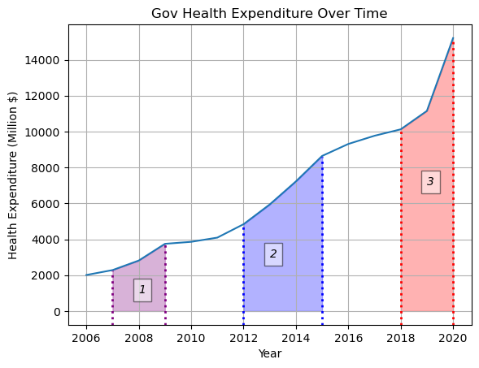

```python
# Import Numpy and Matplotlib, to extract data using numpy and to plot meaningful graphs/plots using matplotlib
import numpy as np
import matplotlib.pyplot as plt

# Load the CSV data
data = np.genfromtxt("GovernmentHealthExpenditure.csv",
delimiter=',',
names=True, dtype=(int, int, int, float, float))

# Extract financial year and health expenditure columns
years = data['financial_year']
expenditure = data['government_health_expenditure']

# Plot the line graph for expenditure over years
plt.plot(years, expenditure)
plt.xlabel('Year')
plt.ylabel('Health Expenditure (Million $)')

# Draw vertical dotted lines at 2007 and 2009
plt.axvline(x=2007, ymin=0, ymax=0.18,
            linewidth=2,
            linestyle="dotted",
            color="purple" )
plt.axvline(x=2009, ymin=0, ymax=0.27,
            linewidth=2,
            linestyle="dotted",
            color="purple" )
# Shade the region between 2007 and 2009
mask1 = (years >= 2007) & (years <= 2009)
plt.fill_between(years, expenditure, where=mask1, color='purple', alpha=0.3)
# Add 1 to label this region
plt.text(2008, 1000, '1', style='italic',
bbox={'facecolor':'white', 'alpha':0.5,
'pad':5})

# Draw vertical dotted lines at 2012 and 2015
plt.axvline(x=2012, ymin=0, ymax=0.33,
            linewidth=2,
            linestyle="dotted",
            color="blue" )
plt.axvline(x=2015, ymin=0, ymax=0.56,
            linewidth=2,
            linestyle="dotted",
            color="blue" )
# Fill the region between 2012 and 2015
mask2 = (years >= 2012) & (years <= 2015)
plt.fill_between(years, expenditure, where=mask2, color='blue', alpha=0.3)
# Add 2 to label this region
plt.text(2013, 3000, '2', style='italic',
bbox={'facecolor':'white', 'alpha':0.5,
'pad':5})

# Draw vertical dotted lines at 2018 and 2020
plt.axvline(x=2018, ymin=0, ymax=0.65,
            linewidth=2,
            linestyle="dotted",
            color="red" )
plt.axvline(x=2020, ymin=0, ymax=0.95,
            linewidth=2,
            linestyle="dotted",
            color="red" )
# Fill the region between 2018 and 2020
mask3 = (years >= 2018) & (years <= 2020)
plt.fill_between(years, expenditure, where=mask3, color='red', alpha=0.3)
# Add 3 to label this region
plt.text(2019, 7000, '3', style='italic',
bbox={'facecolor':'white', 'alpha':0.5,
'pad':5})

# Set specific y-axis ticks
plt.yticks([0,2000,4000,6000,8000,10000,12000,14000])

# Add a title and grid
plt.title('Gov Health Expenditure Over Time')
plt.grid(True)

# Display the final plot
plt.show()
```

```python
# Import Numpy, to extract data using numpy
import numpy as np

# Load the CSV data
data = np.genfromtxt("GovernmentHealthExpenditure.csv",
delimiter=',',
names=True, dtype=(int, int, int, float, float))

# Extract years and government health expenditure columns
years = data['financial_year']
expenditure = data['government_health_expenditure']\


# Region 1: 2007 to 2009
low1 = 2007
high1 = 2009

# Loop through the data to find expenditures for 2007 and 2009
for row in data:
    if row['financial_year'] == low1:
        exp_low1 = row['government_health_expenditure']
    if row['financial_year'] == high1:
        exp_high1 = row['government_health_expenditure']
        break                                             # Stop loop once high value is found
# Calculate and round the increment
increment1 = exp_high1 - exp_low1
increment1 = round(increment1, 2)
# Print result for region 1
print(f"Health expenditure in region 1 increased by {increment1} million dollars\n")

# Region 2: 2012 to 2015
low2 = 2012
high2 = 2015
# Loop through the data to find expenditures for 2012 and 2015
for row in data:
    if row['financial_year'] == low2:
        exp_low2 = row['government_health_expenditure']
    if row['financial_year'] == high2:
        exp_high2 = row['government_health_expenditure']
        break                                              # Stop loop once high value is found
# Calculate and round the increment
increment2 = exp_high2 - exp_low2
increment2 = round(increment2, 2)
# Print result for region 2
print(f"Health expenditure in region 2 increased by {increment2} million dollars\n")

# Region 3: 2018 to 2020
low3 = 2018
high3 = 2020
# Loop through the data to find expenditures for 2018 and 2020
for row in data:
    if row['financial_year'] == low3:
        exp_low3 = row['government_health_expenditure']
    if row['financial_year'] == high3:
        exp_high3 = row['government_health_expenditure']
        break                                                 # Stop loop once high value is found
# Calculate and round the increment
increment3 = exp_high3 - exp_low3
increment3 = round(increment3, 2)
# Print result for region 3
print(f"Health expenditure in region 3 increased by {increment3} million dollars\n")

regions = [increment1, increment2, increment3]    # Store increments in a list
highest = np.max(regions)     # Find the highest increment value
highest_index = np.argmax(regions)       # Find the index of the highest increment

# Print which region had the highest increment
print(f"The region with highest increment in health expeniture is {highest_index + 1} with the increment at {highest}")
# Print final Analysis Statement
print("This line graph illustrates a consistent upward trend in Singapore’s governmenthealthcare expenditure over the years,\nsuggesting a growing emphasis on health-related priorities. Notably, the periods from 2007 to 2009, 2012 to 2014, and 2018 to 2020\nexhibit the most significant spikes in spending. These surges may correspond to policy shifts, healthcare reforms\nor responses to disease outbreaks, reflecting moments when the government intensified its investment in public health infrastructure and services.")
```

[output not shown]